# Labor Unions Under Neoliberalism: Part II

Workers Involved in Strikes and Lockouts by Industry 1983-2023

Author

Humberto Rivas

Published

August 25, 2025

## Accessing the Data

I produced the following visualization using the International Labor Organization’s (2025) [ILOSTAT data explorer](https://rshiny.ilo.org/dataexplorer41/?lang=en&id=STR_WORK_ECO_NB_A). On the left-hand side, you will see the “Filter” options, where you can select country and years. Be sure to click “none” in the first 3 boxes and set them in the following order: Northern America, United States of America, and each of the “Aggregate” categories excluding “Aggregate: Total” and “Aggregate: Not classified.” Lastly, drag the slider to the left until you reach 1983.

## Notes

If you add the annual numbers of striking workers by industry, you will notice the totals resemble the US Bureau of Labor Statistics’ (2025) [data](https://www.bls.gov/web/wkstp/annual-listing.htm). Namely, the sums match or fall in between the stoppages “beginning” and “in effect” numbers. You can read more on that terminology [here](https://www.bls.gov/opub/hom/wsp/concepts.htm#stoppages-in-effect) (BLS, 2019). The BLS only counts “work stoppages involving 1,000 or more workers” (2019), whereas the ILO (2025) only adheres to this method from 2009-2014. From 2015-2023, the ILO (2025) includes stoppages involving 500 or more workers.

You can see this disclaimer in the Excel or CSV files of the ILO table. This difference could explain why the ILO data matches the BLS’ “beginning” totals in some years and matches the “in effect” totals in others. At the same time, these measurements suggest that it is wrong to assume a particular sector had 0 striking workers for a given year. These industries could have experienced strikes, but they were on such a small scale neither the BLS nor the ILO included them in the data. On a minor note, the ILO data for 1983-1991 appear less than the BLS sums because I excluded the “Aggregate: Not Classified” category.

## Visualization

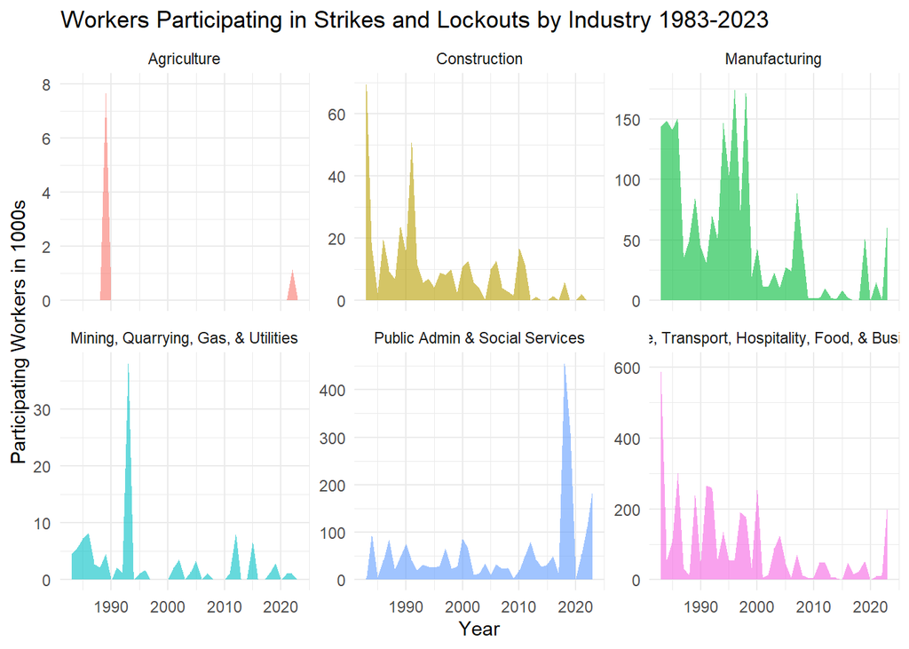

## Discussion

Each small multiple area chart has worker participation (in 1000s) as the y-axis and year as the x-axis. The 6 sectors from the ILO data are: Agriculture, Construction, Manufacturing, Mining and Quarrying (including utilities), Public Administration and Social Services, and Trade (from transportation to hospitality). As I mentioned before, the gaps found in some industries do not necessarily mean these sectors had no strikes. Perhaps the BLS and ILO did not store this data because the number of striking workers was <500.

Construction had a similar trajectory, except its decline of striking workers came after the Great Recession. Approximately 70,000 construction employees went on strike in 1983. In 2010, only around 17,000 laborers went on strike and the number never recovered in the ensuing years. Public Administration, Mining, and Agriculture are interesting cases because they have a stagnant amount of striking employees. From 1983 to 2017, less than 100,000 Public Administration workers went on the picket line. Astonishingly, some 450,000, 320,000, 100,000, and 190,000 civil servants walked off the job in the years 2018, 2019, 2022, and 2023, respectively.

Unfortunately, the ILO only has two years (1989 and 2022) of solid data for Agriculture strikes. There are multiple reasons for this uninformative chart. First, the US Census Bureau’s Current Population Survey “samples of farm workers are small, and the CPS did not report median weekly wages” for agricultural union members (Rural Migration News, 2023). Second, BLS data on agricultural unions only dates back to 2000. If you visit the BLS (2015) [Data Retrieval](https://www.bls.gov/webapps/legacy/cpslutab4.htm) tool and select any box related to agriculture, you will see that is as far back as the data goes. Third, even with this minute sample size, merely 48,000 of the 1.3 million workers in the agriculture industry are union members (Rural Migration News, 2023).

These conditions force the ILO to discard perhaps multiple small-scale strikes on the agricultural front. If we are speaking in economic terms, we are not even getting to how agricultural workers’ migration status complicates union participation, let alone strikes. For example, the latest USDA (2025) data finds that between 2020 and 2022, 42% of hired crop farm workers held no work authorization. Moreover, the growing number of H-2A (Temporary Agricultural Program) visa applicants, whose average stay was 5.75 months in 2023, are not included in the Labor Department’s National Agricultural Workers Survey (USDA, 2025). Seasonal migration, uncertain citizenship status, and the fact that some migrants live in right-to-work states significantly depress the strike potential of agricultural laborers.

## Works Cited

Bureau of Labor Statistics. (2015, September 16). *Data Retrieval: Labor Force Statistics (CPS) - Table 4. Median weekly earnings of full-time wage and salary workers by union affiliation, occupation, and industry*. https://www.bls.gov/webapps/legacy/cpslutab4.htm

Bureau of Labor Statistics. (2025, February 20). *Major Work Stoppages: Annual summary data*. https://www.bls.gov/web/wkstp/annual-listing.htm

Bureau of Labor Statistics. (2019, January 23). *Work Stoppages: Concepts*. https://www.bls.gov/opub/hom/wsp/concepts.htm#stoppages-in-effect

International Labor Organization. (2025, February 9). *ILOSTAT Data Explorer: Workers involved in strikes and lockouts by economic activity (thousands) - Annual*. https://rshiny.ilo.org/dataexplorer41/?lang=en&id=STR_WORK_ECO_NB_A

Rural Migration News. (2023, April 7). Unions: 10% of US Workers, 1% of Farm Workers. *University of California, Davis*. https://migration.ucdavis.edu/rmn/blog/post/?id=2836

US Department of Agriculture. (2025, January 8). *Farm Labor*. https://www.ers.usda.gov/topics/farm-economy/farm-labor